# Random Variables

Abel Isaias Gutierrez-Cruz

29/11/2021

## Exercise 7.1

Consider the following cumulative distribution function of a random variable X :

$F(x) = \left\{ \begin{array}{ll} 0 & if \enspace x < 2 \\ -\dfrac{1}{4}x^2 + 2x - 3 & if \enspace 2 \leq x \leq 4 \\ 1 & if \enspace x > 4 \end{array} \right.$

##### a. What is the PDF of X ?

$\frac{d}{dx}0 = 0$

$\frac{d}{dx} -\dfrac{1}{4}x^2 + 2x - 3 = - \frac{1}{2}x + 2$

$\frac{d}{dx} 1 = 0$

$\therefore F'(X) = \left\{ \begin{array}{ll} 0 & if \enspace x < 2 \\ -\dfrac{1}{2}x + 2 & if \enspace 2 \leq x \leq 4 \\ 0 & if \enspace x > 4 \end{array} \right.$

##### b. Calculate P(X < 3) and P(X = 4).

- Given theorem $P(X=x_0) = 0$ $P(X=4) = 0$
- $P(X<3) = P(X \leq 3) - P(X=3) = -\dfrac{1}{4}*3^2 + 2*3 - 3 - 0 =$ 0.75

##### c. Determine $E(X)$ and $Var(X)$

$E(X) = \displaystyle{\int_{-\infty}^\infty x f(x) dx = \int_{-\infty}^2 xf(x)dx + \int_2^4 x f(x)dx + \int_4^\infty xf(x)dx}$

$\displaystyle{=0 + \int_2^4 (-\frac{1}{2}x^2 + 2x) dx + 0 = \left[ - \frac{x^3}{6} + x^2 \right]^4_2 = (-\frac{4^3}{6} + 4^2) - (-\frac{2^3}{6} + 2^2)} = \frac{8}{3}=$ 2.6666667

$\displaystyle{Var(X) = E(X^2) - [E(X)]^2}$

$\displaystyle{E(X^2) = \int_2^4 (-\frac{1}{2}x^3 + 2x^2) dx = \left[ -\frac{x^4}{8} + \frac{2}{3}x^3 \right]_2^4 = (-\frac{4^4}{8} +\frac{2}{3}4^3)- (- \frac{2^4}{8} + \frac{2}{3}2^3) =\frac{22}{3} =}$ 7.3333333

$Var(X) = \frac{22}{3} - (\frac{8}{3})^2 =\frac{2}{9}$

## Exercise 7.2

Joey manipulates a die to increase his chances of winning a board game against his friends. In each round, a die is rolled and larger numbers are generally an advantage. Consider the random variable X denoting the outcome of the rolled die and the respective probabilities $P(X = 1 = 2 = 3 = 5) = 1/9$, $P(X = 4) = 2/9$, and $P(X = 6) = 3/9$

##### a. Calculate and interpret the expectation and variance of X .

$E(X)=\sum\limits_{i=1}^kx_ip_i=x_1P(X=x_1)+x_2P(X=x_2)+ ... + x_kP(X=x_k) \tag{16}$

$E(X) = \sum\limits_{i=1}^6x_ip_i = (1 + 2 + 3 +5)\frac{1}{9} + 4 \cdot \frac{2}{9} + 6 \cdot \frac{3}{9} = \frac{37}{9} \approx$ 4.1111111

$E(X^2) = \sum\limits_{i=1}^6x_ip_i = (1^2 + 2^2 + 3^2 +5^2)\frac{1}{9} + 4^2 \cdot \frac{2}{9} + 6^2 \cdot \frac{3}{9} = \frac{179}{9} \approx$ 19.8888889

$\displaystyle{Var(X) = E(X^2) - [E(X)]^2}$

##### b. Imagine that the board game contains an action which makes the players use $1/X$ rather than $X$ . What is the expectation of $Y = 1/X$ ? Is $E(Y ) = E(1/ X ) = 1/E(X)$?

Given the prior instructions: $P(X = \frac{1}{1} = \frac{1}{2} = \frac{1}{3} = \frac{1}{5}) = 1/9$, $P(X = \frac{1}{4}) = 2/9$, and $P(X = \frac{1}{6}) = 3/9$

$E(Y) = \sum\limits_{i=1}^6x_ip_i = (1 + \frac{1}{2} + \frac{1}{3} +\frac{1}{5})\frac{1}{9} + \frac{1}{4} \cdot \frac{2}{9} + \frac{1}{6} \cdot \frac{3}{9} = \frac{91}{270} \approx$ 0.337037

## Exercise 7.3

An innovative winemaker experiments with new grapes and adds a new wine to his stock. The percentage sold by the end of the season depends on the weather and various other factors. It can be modeled using the random variable $X$ with the CDF as

$F(x) = \left\{ \begin{array}{ll} 0 & if \enspace x < 0 \\ 3x^2 - 2x^3 & if \enspace 0 \leq x \leq 1 \\ 1 & if x > 1 \end{array} \right.$

##### a. Plot the cumulative distribution function with R.

To consider the behavior in each interval of the function, we multiply each behavior of the data by a logical condition.

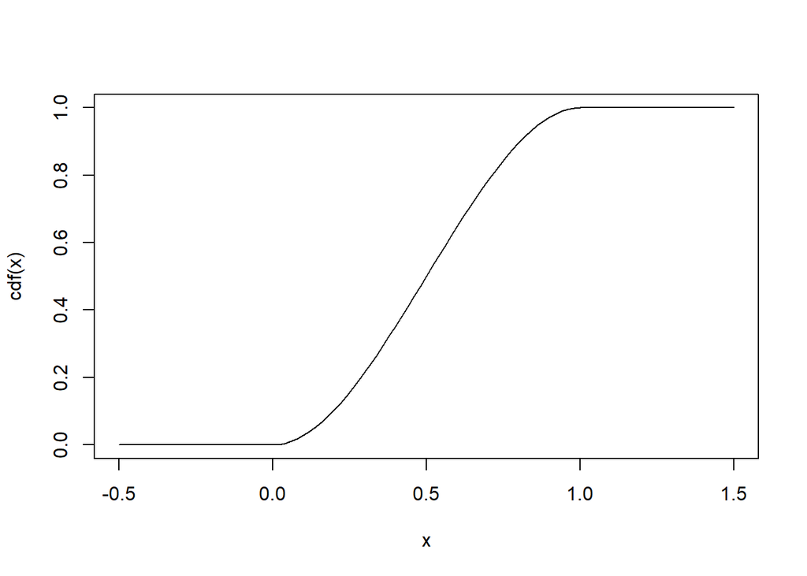

```r
cdf <- function(x){(3*x^2 - 2*x^3) * (x >= 0 & x <= 1) + 1*(x>1) + 0*(x<0)}
curve(cdf, from=-0.5, to=1.5)
```

##### b. Determine $f(x)$

$\frac{d}{dx} F(x)= (3x^2-2x^3)d/dx = 6x - 6x^2$

$\therefore f(x) = \left\{ \begin{array}{ll} 6(x - x^2) & if \enspace 0 \leq x \leq 1 \\ 0 & elsewhere \end{array} \right.$

##### c. What is the probability of selling at least one-third of his wine, but not more than two thirds?

$F(\frac{2}{3}) - F(\frac{1}{3}) = \left( 3(\frac{2}{3})^2 + 2(\frac{2}{3})^3 \right) - \left( 3(\frac{1}{3})^2 + 2(\frac{1}{3})^3 \right) =$ 0.4814815

##### d. Define the CDF in R and calculate the probability of c) again.

```r
cdf(2/3) - cdf(1/3)
```

```
## [1] 0.4814815
```

##### e. What is the variance of X?

$\displaystyle E(X) = \int_{-\infty}^\infty xf(x) dx = \int_{-\infty}^0xf(x)dx + \int_0^1xf(x)dx + \int_1^\infty xf(x)dx=$

$\displaystyle 0 + \int_0^1xf(x)dx + 0 = 6\left[ \frac{x^3}{3} - \frac{x^4}{4} \right]^1_0 = 6\left( \frac{1}{3} - \frac{1}{4} \right) =$ 0.5

$E(X^2) = \displaystyle 0 + \int_0^1x^2f(x)dx + 0 = 6\left[ \frac{x^4}{4} - \frac{x^5}{5} \right]^1_0 = 6\left( \frac{1}{4} - \frac{1}{5} \right) =$ 0.3

$Var(X) = E(X^2) - [E(X)]^2 =0.3 - 0.5^2 =$ 0.05

## Exercise 7.4

A quality index summarizes different features of a product by means of a score. Different experts may assign different quality scores depending on their experience with the product. Let $X$ be the quality index for a tablet. Suppose the respective probability density function is given as follows:

$f(x) = \left\{ \begin{array}{ll} cx(2-x) & if \enspace 0 \leq x \leq 2 \\ 0 & elsewhere \end{array} \right.$

##### a. Determine c such that $f(x)$ is a proper PDF.

Conditions:

- $\int_{-\infty}^\infty f(x)dx = 1$

$\displaystyle \int_0^2 c \cdot x(2-x) dx = c \int_0^2 2x - x^2 = c \cdot \left[ x^2 - \frac{x^3}{3} \right]_0^2 = c \cdot \frac{4}{3}$

$c \cdot \frac{4}{3} = 1$

$c = \frac{3}{4}$

- $f(x) \geq 0 \enspace for \enspace all \enspace x \in R$

$f(x) = \frac{3}{4} x(2-x) \geq 0 \enspace \forall \enspace x \in [0, 2]$

##### b. Determine the cumulative distribution function.

$\displaystyle F(X) = \int_{0}^x f(t) dt = \int_0^x \frac{3}{4}x(2-x)dt = \frac{3}{4} \int_0^x2t - t^2$

$\displaystyle \frac{3}{4}(t^2 - \frac{t^3}{3}) = \frac{3}{4}x^2(1-\frac{x}{3})$

$\therefore F(X) = \left\{ \begin{array}{ll} 0 & if \enspace x <0 \\ \frac{3}{4}x^2(1-\frac{x}{3}) & if \enspace 0 \leq x \leq 2 \\ 1 & if \enspace x > 2 \end{array} \right.$

##### c. Calculate the expectation and variance of X .

$\displaystyle E(X) = \int_{-\infty}^\infty x f(x)dx = \frac{3}{4} \int_0^2 (2x^2 - x^3)dx = \frac{3}{4} \cdot \left[ \frac{2x^3}{3} -\frac{x^4}{4}\right]_0^2 =$

$\displaystyle \frac{3}{4} \cdot \left( \frac{16}{3} - 4\right) = \frac{3}{4} \cdot \frac{4}{3} = 1$

$\displaystyle E(X^2) = \int_{-\infty}^\infty x f(x)dx = \frac{3}{4} \cdot \left[ \frac{2x^4}{4} -\frac{x^5}{5}\right]_0^2 = \frac{3}{4} \cdot \left( \frac{32}{4} - \frac{32}{5} \right) = \frac{6}{5}$

$\displaystyle Var(X) = \frac{6}{5} - 1^2 = \frac{1}{5}$

##### d. Use Tschebyschev’s inequality to determine the probability that X does not deviate more than 0.5 from its expectation.

$P(|X - \mu| < 0.5) \geq 1 - \frac{\frac{1}{5}}{0.5^2} = 1 - 0.8 = 0.2$

## Exercise 7.5

Consider the joint PDF for the type of customer service $X (0 = telephonic \enspace hotline, \enspace 1 = Email)$ and of satisfaction score $Y (1 = unsatisfied, \enspace 2 = satisfied, \enspace 3 = very \enspace satisfied)$:

| X/Y | 1 | 2 | 3 |
| --- | --- | --- | --- |
| 0 | 0 | 1/2 | 1/4 |
| 1 | 1/6 | 1/12 | 0 |

##### a. Determine and interpret the marginal distributions of both X and Y

| X | $P(X = x_i)$ |
| --- | --- |
| 0 | 3/4 |
| 1 | 1/4 |

| Y | $P(Y = y_i)$ |
| --- | --- |
| 1 | 1/6 |
| 2 | 7/12 |
| 3 | 1/4 |

##### b. Calculate the 75 $\%$ quantile for the marginal distribution of Y

The 75 $\%$ have to follow:

$F(x_p)\geq p$ $F(x) < p \enspace for \enspace x < x_p$

If we consider those properties, we will found that the third quartile is $X=2$ $F(x = 2) = 1/6 + 7/12 = 9/12$ $F(x=2) \geq 0.75$

##### c. Determine and interpret the conditional distribution of satisfaction level for $X = 1$.

The conditional distribution is given as follows: $\displaystyle P(Y = y_i | X = 1) = p_{j|i} = \frac{p_{ij}}{p_{1+}} = \frac{p_{ij}}{1/4}$

$P(Y = 1 | X = 1) = \frac{1/6}{1/4} = 2/3$

$P(Y = 2 | X = 1) = \frac{1/12}{1/4} = 1/3$

$P(Y = 3 | X = 1) = \frac{0}{1/4} = 0$

The customers using email like customer services are more uncomfortable. The most of them have a level of satisfaction poor (they are unsatisfied)

##### d. Are the two variables independent?

To be independent they have to follow: $P(X = x_i, Y = y_j) = P(X=x_i)P(Y = y_i)$

$P(X = 0, Y = 1) = 3/4 \times 1/6 \neq 0$

##### e. Calculate and interpret the covariance of $X$ and $Y$ .

$Cov(X,Y) = E(XY) - E(X)E(Y)$

$E(XY) = \sum_i \sum_j x_iy_ip_{ij}$

$\displaystyle E(X) = \sum\limits_{i=1}^kx_ip_i = x_1P(X=x_1)+x_2P(X=x_2)+ ... + x_kP(X=x_k)$

$E(X) = 0 \cdot 3/4 + 1 \cdot 3/12 = 1/4$

$E(Y) = 1 \cdot 1/6 + 2 \cdot 7/12 + 3 \cdot 1/4 = \frac{25}{12}$

$E(XY) = 0 \cdot 1 \cdot 0 + 0 \cdot 2 \cdot 1/2 + 0 \cdot 3 \cdot 1/4 + 1 \cdot 1 \cdot 1/6 + 1\cdot 2\cdot 1/12 + 1 \cdot 3\cdot 0 = \frac{2}{6}$

$Cov(X,Y) = \frac{2}{6} - \frac{25}{12} \cdot \frac{1}{4} =$ -0.1875

The value of covariance between X and Y is negative, so we could say that high values of X have low values of Y.

## Exercise 7.6

Consider a continuous random variable X with expectation 15 and variance 4. Determine the smallest interval $[15 − c, 15 + c]$ which contains at least 90 $\%$ of the values of X .

$P(|X -15 | < c) = 0.9 \geq 1 - \frac{4}{c^2}$

$c = \sqrt{\dfrac{4}{0.1}}$

$c = \pm$ 6.3245553

$[15 -$ 6.3245553 $, 15 +$ 6.3245553 $]$

## Exercise 7.7

Let X and Y be two random variables for which only 6 possible events— $A1, A2, A3, A4, A5, A6$—are defined:

| i | 1 | 2 | 3 | 4 | 5 | 6 |
| --- | --- | --- | --- | --- | --- | --- |
| $P(A_i)$ | 0.3 | 0.1 | 0.1 | 0.2 | 0.2 | 0.1 |
| $X_i$ | -1 | 2 | 2 | -1 | -1 | 2 |
| $Y_i$ | 0 | 2 | 0 | 1 | 2 | 1 |

##### a. What is the joint PDF of $X$ and $Y$?

| X /Y | 0 | 1 | 2 |
| --- | --- | --- | --- |
| -1 | 0.3 | 0.2 | 0.2 |
| 2 | 0.1 | 0.1 | 0.1 |

##### b. Calculate the marginal distributions of $X$ and $Y$

$P(X_{-1}) = 0.7$

$P(X_2) = 0.3$

$P(Y_0) = 0.4$

$P(Y_1) = 0.3$

$P(Y_2) = 0.3$

##### c. Are both variables independent?

To be independent they have to follow: $P(X = x_i, Y = y_j) = P(X=x_i)P(Y = y_i)$

$P(X=x_{-1}, Y = y_0) = 0.7 \times 0.4 \neq 0.3$

##### d. Determine the joint PDF for $U = X + Y$

-1 | 0 | 1 | 2 | 3 | 4

P(U) | 0.3 | 0.2 | 0.2 | 0.1 | 0.1 | 0.1

##### e. Calculate $E(U)$ and $Var(U)$ and compare it with $E(X) + E(Y)$ and $Var(X) + Var(Y)$, respectively.

$E(U)= -1 \cdot 0.3 + 0 \cdot 0.2 + 1 \cdot 0.2 + 2 \cdot 0.1 + 3 \cdot 0.1 + 4 \cdot 0.1 =$ 0.8

$E(U^2) = (-1)^2 \cdot 0.3 + 0^2 \cdot 0.2 + 1^2 \cdot 0.2 + 2^2 \cdot 0.1 + 3^2 \cdot 0.1 + 4^2 \cdot 0.1 =$ 3.4

$Var(U) = E(X^2)-[E(X)]^2 = 3.4 - 0.8^2 =$ 2.76

$E(X) = - 1 \cdot 0.7 + 2 \cdot 0.3 =$ -0.1

$E(X^2) = - 1^2 \cdot 0.7 + 2^2 \cdot 0.3 =$ 1.9

$Var(X) = E(X^2)-[E(X)]^2 =$ 1.89

$E(Y) = 0 \cdot 0.4 + 1 \cdot 0.3 + 2 \cdot 0.3$ 0.9

$E(Y^2) = 0^2 \cdot 0.4 + 1^2 \cdot 0.3 + 2^2 \cdot 0.3$ 1.5

$Var(Y) = E(Y^2)-[E(Y)]^2 =$ 0.69

## Exercise 7.8

Recall the urn model we introduced in Chap. 5. Consider an urn with eight balls: four of them are white, three are black, and one is red. Now, two balls are drawn from the urn. The random variables $X$ and $Y$ are defined as follows:

$X = \left\{ \begin{array}{ll} 1 & black \enspace ball \\ 2 & red \enspace ball \enspace in \enspace the \enspace first \enspace draw \\ 3 & whtie \enspace ball \end{array} \right.$

$Y = \left\{ \begin{array}{ll} 1 & black \enspace ball \\ 2 & red \enspace ball \enspace in \enspace the \enspace second \enspace draw \\ 3 & whtie \enspace ball \end{array} \right.$

##### a.When are $X$ and $Y$ independent—when the two balls are drawn with replacement or without replacement?

##### b. Assume the balls are drawn such that $X$ and $Y$ are dependent. Use the conditional distribution $P(Y |X)$ to determine the joint PDF of $X$ and $Y$

##### c. Calculate $E(X)$, $E(Y)$, and $ρ(X, Y)$

## Exercise 7.9

If $X$ is the amount of money spent on food and other expenses during a day (in euros) and $Y$ is the daily allowance of a businesswoman, the joint density of these two variables is given by

$f_{XY}(x, y) = \left\{ \begin{array}{ll} c\left( \dfrac{100 -x}{x}\right) & if \enspace 10 \leq x \leq 100, \enspace 40 \leq y \leq 100 \\ 0 & elsewhere \end{array} \right.$

##### a. Choose $c$ such that $f_{XY}(x, y)$ is a probability density function.

##### b. Find the marginal distribution of $X$

##### c. Calculate the probability that more than 75 euros are spent.

##### d. Determine the conditional distribution of $Y$ given $X$

## Exercise 2 7.10

Consider $n$ i.i.d. random $X$ variables $X_i$ with $E(X_i) = \mu$ and $Var(X_i) = \sigma$ and the standardized variable $Y = \sigma −\mu$ . Show that $E(Y ) = 0$ and $Var(Y ) = 1$